# Harmonization exposition : smoking

This report lists the candidate variable for DataScheme variables of the construct **smoking**.

# (I) Exposition

> This report is a record of interaction with a data transfer object (dto) produced by `./manipulation/0-ellis-island.R`.

The next section recaps this script, exposes the architecture of the DTO, and demonstrates the language of interacting with it.

## (I.A) Ellis Island

> All data land on Ellis Island.

The script `0-ellis-island.R` is the first script in the analytic workflow. It accomplished the following:

- 1. Reads in raw data files from the candidate studies
- 2. Extract, combines, and exports their metadata (specifically, variable names and labels, if provided) into `./data/shared/derived/meta-data-live.csv`, which is updated every time Ellis Island script is executed.
- 3. Augments raw metadata with instructions for renaming and classifying variables. The instructions are provided as manually entered values in `./data/shared/meta-data-map.csv`. They are used by automatic scripts in later harmonization and analysis.
- 4. Combines unit and metadata into a single DTO to serve as a starting point to all subsequent analyses.

```r
# load the product of 0-ellis-island.R,  a list object containing data and metadata
dto <- readRDS("./data/unshared/derived/dto.rds")
```

```r
# the list is composed of the following elements
names(dto)
```

```
[1] "studyName" "filePath"  "unitData"  "metaData"
```

```r
# 1st element - names of the studies as character vector
dto[["studyName"]]
```

```
[1] "alsa"  "lbsl"  "satsa" "share" "tilda"
```

```r
# 2nd element - file paths of the data files for each study as character vector
dto[["filePath"]]
```

```
[1] "./data/unshared/raw/ALSA-Wave1.Final.sav"         "./data/unshared/raw/LBSL-Panel2-Wave1.Final.sav"
[3] "./data/unshared/raw/SATSA-Q3.Final.sav"           "./data/unshared/raw/SHARE-Israel-Wave1.Final.sav"
[5] "./data/unshared/raw/TILDA-Wave1.Final.sav"
```

```r
# 3rd element - is a list object containing the following elements
names(dto[["unitData"]])
```

```
[1] "alsa"  "lbsl"  "satsa" "share" "tilda"
```

```r
# each of these elements is a raw data set of a corresponding study, for example
dplyr::tbl_df(dto[["unitData"]][["lbsl"]])
```

```
Source: local data frame [656 x 26]

        id AGE94 SEX94  MSTAT94 EDUC94     NOWRK94  SMK94                                         SMOKE
     (int) (int) (int)   (fctr)  (int)      (fctr) (fctr)                                        (fctr)
1  4001026    68     1 divorced     16 no, retired     no                                  never smoked
2  4012015    94     2  widowed     12 no, retired     no                                  never smoked
3  4012032    94     2  widowed     20 no, retired     no don't smoke at present but smoked in the past
4  4022004    93     2       NA     NA          NA     NA                                  never smoked
5  4022026    93     2  widowed     12 no, retired     no                                  never smoked
6  4031031    92     1  married      8 no, retired     no don't smoke at present but smoked in the past
7  4031035    92     1  widowed     13 no, retired     no don't smoke at present but smoked in the past
8  4032201    92     2       NA     NA          NA     NA don't smoke at present but smoked in the past
9  4041062    91     1  widowed      7          NA     no don't smoke at present but smoked in the past
10 4042057    91     2       NA     NA          NA     NA                                            NA
..     ...   ...   ...      ...    ...         ...    ...                                           ...
Variables not shown: ALCOHOL (fctr), WINE (int), BEER (int), HARDLIQ (int), SPORT94 (int), FIT94 (int), WALK94 (int),
  SPEC94 (int), DANCE94 (int), CHORE94 (int), EXCERTOT (int), EXCERWK (int), HEIGHT94 (int), WEIGHT94 (int), HWEIGHT
  (int), HHEIGHT (int), SRHEALTH (fctr), year_of_wave (dbl)
```

### (I.A.1) Meta

```r
# 4th element - a dataset names and labels of raw variables + added metadata for all studies
dto[["metaData"]] %>% dplyr::select(study_name, name, item, construct, type, categories, label_short, label) %>%
  DT::datatable(
    class   = 'cell-border stripe',
    caption = "This is the primary metadata file. Edit at `./data/shared/meta-data-map.csv",
    filter  = "top",
    options = list(pageLength = 6, autoWidth = TRUE)
  )
```

|  | study_name | name | item | construct | type | categories | label_short | label |
| --- | --- | --- | --- | --- | --- | --- | --- | --- |
| 1 | alsa | SEQNUM | id | id | demo | 2087 | Sequence Number | Sequence Number |
| 2 | alsa | EXRTHOUS | exertion |  | activity |  | Exertion around house | Exertion around house |
| 3 | alsa | HWMNWK2W | walking |  | activity |  | Times walked in past two weeks | Times walked in past two weeks |
| 4 | alsa | LSVEXC2W |  |  | activity |  | Less vigor sessions last 2 weeks | Less vigor sessions last 2 weeks |
| 5 | alsa | LSVIGEXC |  |  | activity |  | Less vigor past 2 weeks | Less vigor past 2 weeks |
| 6 | alsa | TMHVYEXR |  |  | activity |  | Time heavy physical exertion | Time heavy physical exertion |
| 7 | alsa | TMVEXC2W |  |  | activity |  | Vigor Time past 2 weeks | Vigor Time past 2 weeks |
| 8 | alsa | VIGEXC2W |  |  | activity |  | Vigor Sessions in past 2 weeks | Vigor Sessions in past 2 weeks |
| 9 | alsa | VIGEXCS |  |  | activity |  | Vigorous exercise | Vigorous exercise |
| 10 | alsa | WALK2WKS |  |  | activity |  | Walking past 2 weeks | Walking past 2 weeks |

[output cut: 140 more lines]

## (I.B) Target-H

> Everybody wants to be somebody.

We query metadata set to retrieve all variables potentially tapping the construct `smoking`. These are the candidates to enter the DataSchema and contribute to computing harmonized variables.

*NOTE*: what is being retrieved depends on the manually entered values in the column `construct` of the metadata file `./data/shared/meta-data-map.csv`. To specify a different group of variables, edit the metadata, not the script.

```r
meta_data <- dto[["metaData"]] %>%
  dplyr::filter(construct %in% c('smoking')) %>%
  dplyr::select(study_name, name, construct, label_short, categories, url) %>%
  dplyr::arrange(construct, study_name)
knitr::kable(meta_data)
```

| study_name | name | construct | label_short | categories | url |
| --- | --- | --- | --- | --- | --- |
| alsa | SMOKER | smoking | Do you currently smoke cigarettes? | 2 | [link](https://www.maelstrom-research.org/mica/variable/alsa_wave1%3Asmoker%3AStudy) |
| alsa | PIPCIGAR | smoking | Do you regularly smoke pipe or cigar? | 2 | [link](https://www.maelstrom-research.org/mica/variable/alsa_wave1%3Apipcigar%3AStudy) |
| lbsl | SMK94 | smoking | Currently smoke? | 2 | [link](https://www.maelstrom-research.org/mica/variable/lbls-1994%3ASMK%5Byear%5D%3AStudy) |
| lbsl | SMOKE | smoking | Smoke, tobacco use | 3 | [link](https://www.maelstrom-research.org/mica/variable/lbls-1994%3ASMOKE%5Byear%5D%3AStudy) |
| satsa | GEVRSMK | smoking | Do you smoke tobacco? | 3 | [link](https://www.maelstrom-research.org/mica/variable/satsa_q3%3AGEVRSMK%3AStudy) |
| satsa | GEVRSNS | smoking | Do you take snuff? | 3 | [link](https://www.maelstrom-research.org/mica/variable/satsa_q3%3AGEVRSNS%3AStudy) |
| satsa | GSMOKNOW | smoking | Smoked some last month? | 2 | [link](https://www.maelstrom-research.org/mica/variable/satsa_q3%3AGSMOKNOW%3AStudy) |
| share | BR0010 | smoking | Ever smoked tobacco daily for a year? | 2 | [link](http://wiki.obiba.org/display/MHSA2016/The+Survey+of+Health%2C+Ageing+and+Retirement+in+Europe+%28SHARE%29+-+Israel) |
| share | BR0020 | smoking | Smoke at present? | 2 | [link](http://wiki.obiba.org/display/MHSA2016/The+Survey+of+Health%2C+Ageing+and+Retirement+in+Europe+%28SHARE%29+-+Israel) |
| share | BR0030 | smoking | How many years smoked? | NA |  |
| tilda | BH001 | smoking | Ever smoked tobacco daily for a year? | 2 | [link](https://www.maelstrom-research.org/mica/variable/tilda-wave1%3Abh001%3AStudy) |
| tilda | BH002 | smoking | Smoke at present? | 2 | [link](https://www.maelstrom-research.org/mica/variable/tilda-wave1%3Abh002%3AStudy) |
| tilda | BH003 | smoking | Age when stopped smoking | NA |  |
| tilda | BEHSMOKER | smoking | Respondent is a smoker | 3 | [link](https://www.maelstrom-research.org/mica/variable/tilda-wave1%3ABEHsmoker%3AStudy) |

View descriptives : smoking for closer examination of each candidate. After reviewing these descriptives and relevant codebooks, the following operationalization of the harmonized variables for `smoking` have been adopted:

#### (1) `smoke_now` : **Are you a smoker presently?**

- `0` - NO - *healthy choice*
- `1` - YES - *unhealthy choice*

#### (2) `smoked_ever` **Have you ever smoked?**

- `0` - NO - *healthy choice*
- `1` - YES - *unhealthy choice*

These two variables will be manufactured by qualitative harmonization in the Development section.

# (II) Development

In this section we will define the schema sets for harmonizing `smoking` construct (i.e. specify which variables from which studies will be contributing to computing harmonized variables ). Each of these schema sets (e.g. `"alsa" = c("SMOKER", "PIPCIGAR")`) will have a particular pattern of possible response values to these variables(e.g. “id_1” = c(“SMOKER”=“YES”, “PIPCIGAR”=“NO”)), which we will export for inspection as `.csv` tables. We then will manually edit these `.csv` tables, populating new columns that will map values of harmonized variables to the specific response pattern of the schema set variables. We then will import harmonization algorithms encoded in `.csv` tables and apply them to compute harmonized variables in the dataset combining raw and harmonized variables for `smoking` construct across studies.

## (II.A)

### (1) Categorization

Preliminary inspection of the schema sets variables revealed two continuous measures:

```r
dto[["metaData"]] %>% dplyr::filter(study_name=="share", name=="BR0030") %>% dplyr::select(name,label)
```

```
    name                 label
1 BR0030 how many years smoked
```

```r
dto[["metaData"]] %>% dplyr::filter(study_name=="tilda", name=="BH003") %>% dplyr::select(name,label)
```

```
   name                                             label
1 BH003 bh003  How old were you when you stopped smoking?
```

After examining their distribution and consulting relevant literature, we have constructed the following rules for transforming these continuous variables into categorical.

#### Recode variable `BR0030` in SHARE

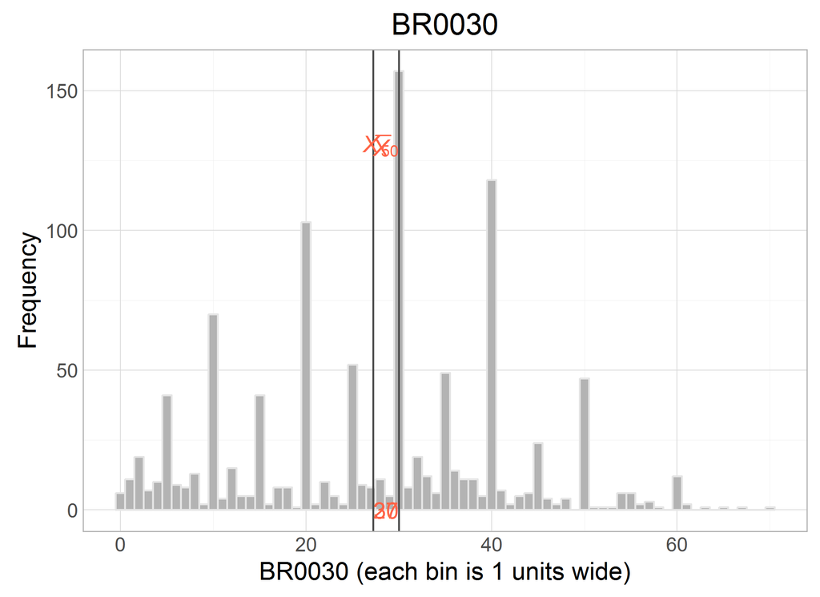

```r
dto[["unitData"]][["share"]] %>% dplyr::filter(!BR0030==9999) %>% histogram_continuous("BR0030", bin_width=1)
```

```r
# categorize continuous variable BR0030 of SHARE
ds <- dto[["unitData"]][["share"]]

ds$BR0030_F[ds$BR0030 == 0]                      <- "less than 1"
ds$BR0030_F[ds$BR0030 > 1  & ds$BR0030 <= 10   ] <- "1-10 years"
ds$BR0030_F[ds$BR0030 > 11 & ds$BR0030 <= 20  ] <- "11-20 years"
ds$BR0030_F[ds$BR0030 > 21 & ds$BR0030 <= 30  ] <- "21-30 years"
ds$BR0030_F[ds$BR0030 > 31 & ds$BR0030 <= 40  ] <- "31-40 years"
ds$BR0030_F[ds$BR0030 > 41 & ds$BR0030 <= 50  ] <- "41-50 years"
ds$BR0030_F[ds$BR0030 > 51                    ] <- "51+ years"
ds$BR0030_F[ds$BR0030 == 9999                  ] <- NA
# convert to an ordered factor
order_in_factor <- c("less than 1","1-10 years","11-20 years","21-30 years","31-40 years","41-50 years","51+ years")
ds$BR0030_F <- ordered(ds$BR0030_F, labels = order_in_factor)
ds %>% dplyr::group_by(BR0030_F) %>% dplyr::summarize(count=n())
```

```
Source: local data frame [8 x 2]

     BR0030_F count
       (fctr) (int)
1 less than 1   179
2  1-10 years   188
3 11-20 years   259
4 21-30 years   245
5 31-40 years    94
6 41-50 years    38
7   51+ years     6
8          NA  1589
```

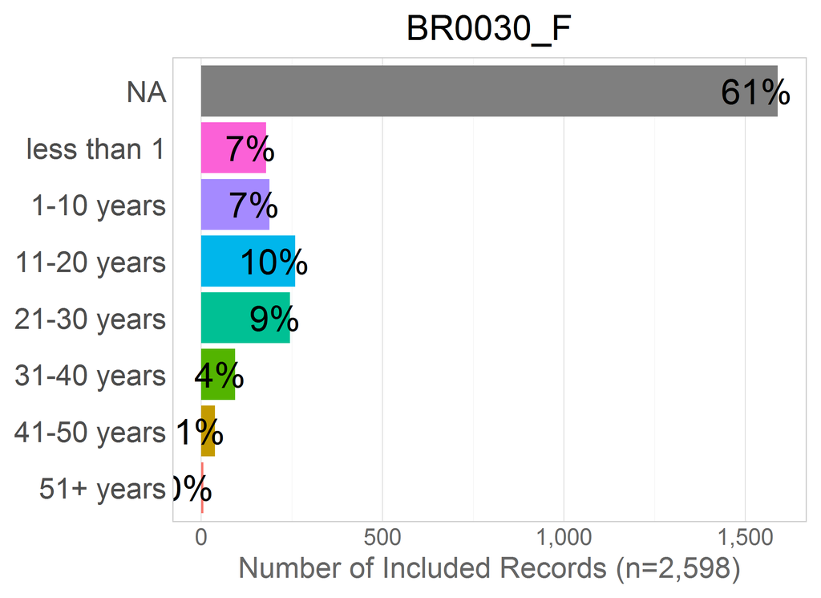

```r
# attach modified dataset to dto, local to this report
dto[["unitData"]][["share"]] <- ds
dto[["unitData"]][["share"]] %>% histogram_discrete("BR0030_F")
```

#### Recode variable `BH003` in TILDA

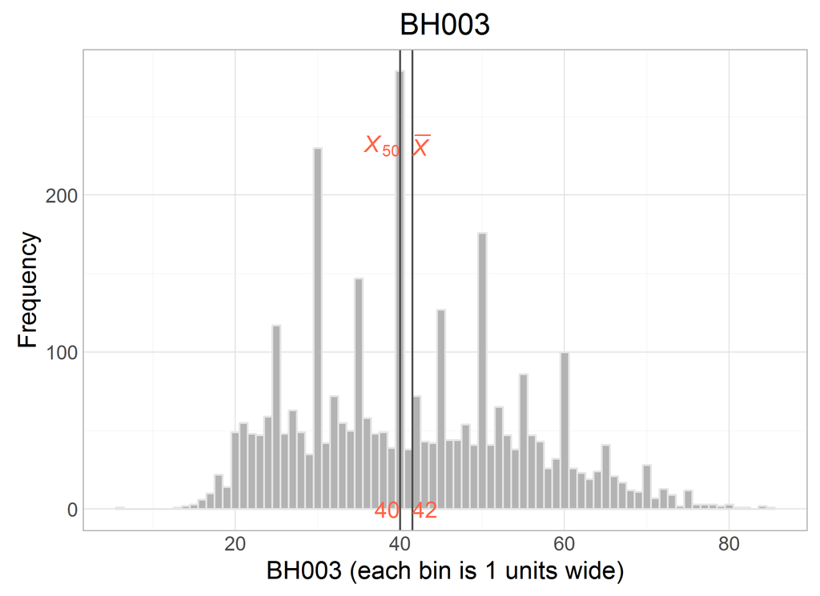

```r
dto[["unitData"]][["tilda"]] %>% dplyr::filter(!BH003==-1) %>% histogram_continuous("BH003", bin_width=1)
```

```r
# categorize continuous variable BH003 of TILDA
ds <- dto[["unitData"]][["tilda"]]
ds$BH003_F <- car::Recode(ds$BH003, "  -1 = NA;
                                    lo:25 ='YOUNG';
                                    26:50 = 'ADULT';
                                    51:75 = 'MIDDLEAGED';
                                    75:hi = 'OLD'")
# convert to an ordered factor
order_in_factor <- c("YOUNG","ADULT","MIDDLEAGED","OLD")
ds$BH003_F <- ordered(ds$BH003_F, labels = order_in_factor)
ds %>% dplyr::group_by(BH003_F) %>% dplyr::summarize(count=n())
```

```
Source: local data frame [5 x 2]

     BH003_F count
      (fctr) (int)
1      YOUNG  1945
2      ADULT   790
3 MIDDLEAGED    19
4        OLD   434
5         NA  5316
```

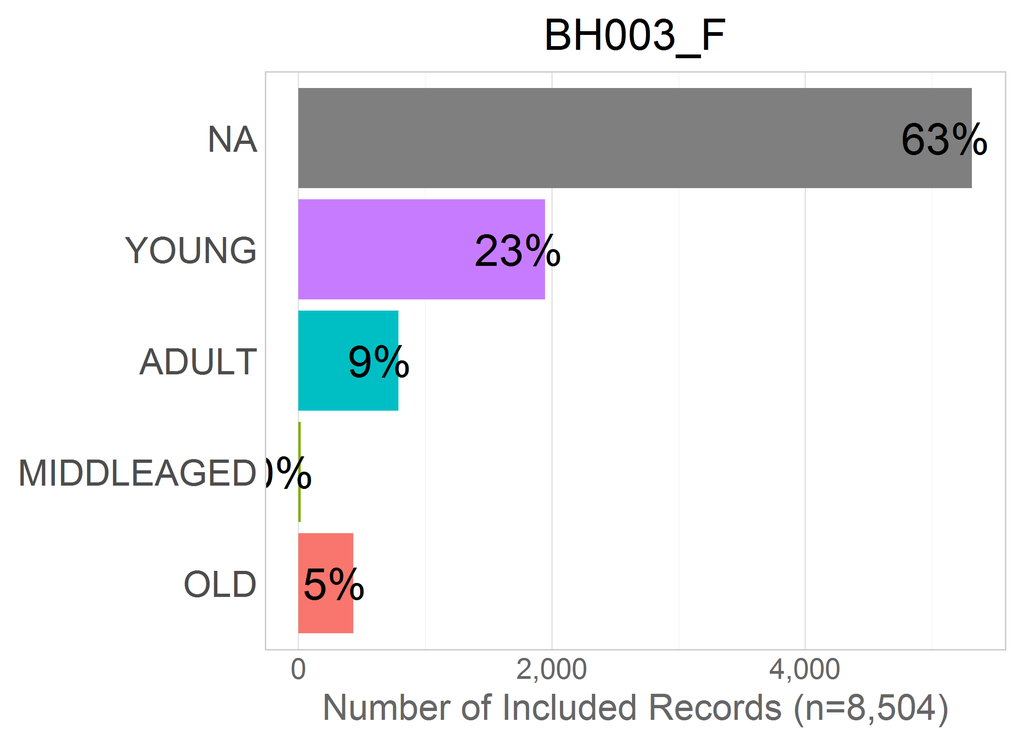

```r
# attach modified dataset to dto, local to this report
dto[["unitData"]][["tilda"]] <- ds
dto[["unitData"]][["tilda"]] %>% histogram_discrete("BH003_F")
```

### (2) Schema sets

Having all potential variables in categorical format we have defined the sets of data schema variables thus:

```r
schema_sets <- list(
  "alsa" = c("SMOKER", "PIPCIGAR"),
  "lbsl" = c("SMK94","SMOKE"),
  "satsa" = c("GSMOKNOW", "GEVRSMK","GEVRSNS"),
  "share" = c("BR0010","BR0020","BR0030_F" ), # "BR0030" is continuous
  "tilda" = c("BH001","BH002", "BEHSMOKER","BH003_F") # "BH003" is continuous
)
```

Each of these schema sets have a particular pattern of possible response values, for example:

```r
# view the joint profile of responses
dto[["unitData"]][["alsa"]] %>%
  dplyr::group_by(SMOKER, PIPCIGAR) %>%
  dplyr::summarize(count = n())
```

```
Source: local data frame [5 x 3]
Groups: SMOKER [?]

  SMOKER PIPCIGAR count
  (fctr)   (fctr) (int)
1    Yes      Yes     7
2    Yes       No   169
3     No      Yes    41
4     No       NA  1851
5     NA       NA    19
```

We output these tables into self-standing `.csv` files, so we can manually provide the logic of computing harmonized variables.

```r
# define function to extract profiles
response_profile <- function(dto, h_target, study, varnames_values){
  ds <- dto[["unitData"]][[study]]
  varnames_values <- lapply(varnames_values, as.symbol)   # Convert character vector to list of symbols
  d <- ds %>%
    dplyr::group_by_(.dots=varnames_values) %>%
    dplyr::summarize(count = n())
  write.csv(d,paste0("./data/meta/response-profiles-live/",h_target,"-",study,".csv"))
}
# extract response profile for data schema set from each study
for(s in names(schema_sets)){
  response_profile(dto,
                   study = s,
                   h_target = 'smoking',
                   varnames_values = schema_sets[[s]]
                   )
}
```

## (II.B) `smoke_now`

#### **Are you a smoker presently?**

- `0` - NO - *healthy choice*
- `1` - YES - *unhealthy choice

### ALSA

Items that can contribute to generating values for the harmonized variable `smoke_now` are:

```r
dto[["metaData"]] %>%
  dplyr::filter(name %in% c("SMOKER", "PIPCIGAR")) %>%
  dplyr::select(study_name, name, label,categories)
```

```
  study_name     name                                 label categories
1       alsa   SMOKER    Do you currently smoke cigarettes?          2
2       alsa PIPCIGAR Do you regularly smoke pipe or cigar?          2
```

We encode the harmonization rule by manually editing the values in a corresponding `.csv` file located in `./data/meta/h-rules/`. Then, we apply the recoding logic it contains and append the newly created, harmonized variable to the initial data set.

```r
study_name <- "alsa"
path_to_hrule <- "./data/meta/h-rules/h-rules-smoking-alsa.csv"
dto[["unitData"]][[study_name]] <- recode_with_hrule(
  dto,
  study_name = study_name,
  variable_names = c("SMOKER", "PIPCIGAR"),
  harmony_name = "smoke_now"
)
```

```
Source: local data frame [5 x 4]
Groups: SMOKER, PIPCIGAR [?]

  SMOKER PIPCIGAR smoke_now     n
   (chr)    (chr)     (lgl) (int)
1     No      Yes      TRUE    41
2     No       NA     FALSE  1851
3    Yes       No      TRUE   169
4    Yes      Yes      TRUE     7
5     NA       NA        NA    19
```

```r
# verify
dto[["unitData"]][["alsa"]] %>%
  dplyr::filter(id %in% sample(unique(id),10)) %>%
  dplyr::select_("id", "SMOKER", "PIPCIGAR", "smoke_now")
```

```
      id SMOKER PIPCIGAR smoke_now
1   1301    Yes       No      TRUE
2   7622     No     <NA>     FALSE
3   8881     No     <NA>     FALSE
4   9721     No     <NA>     FALSE
5  12591     No     <NA>     FALSE
6  13182     No     <NA>     FALSE
7  17201     No     <NA>     FALSE
8  17232     No     <NA>     FALSE
9  20731     No     <NA>     FALSE
10 28282     No     <NA>     FALSE
```

### LBSL

Items that can contribute to generating values for the harmonized variable `smoke_now` are:

```r
dto[["metaData"]] %>%
  dplyr::filter(study_name == "lbsl", construct == "smoking") %>%
  # dplyr::filter(name %in% c("SMK94", "SMOKE")) %>%
  dplyr::select(study_name, name, label_short,categories)
```

```
  study_name  name        label_short categories
1       lbsl SMK94   Currently smoke?          2
2       lbsl SMOKE Smoke, tobacco use          3
```

We encode the harmonization rule by manually editing the values in a corresponding `.csv` file located in `./data/meta/h-rules/`. Then, we apply the recoding logic it contains and append the newly created, harmonized variable to the initial data set.

```r
study_name <- "lbsl"
path_to_hrule <- "./data/meta/h-rules/h-rules-smoking-lbsl.csv"
dto[["unitData"]][[study_name]] <- recode_with_hrule(
  dto,
  study_name = study_name,
  variable_names = c("SMK94", "SMOKE"),
  harmony_name = "smoke_now"
)
```

```
Source: local data frame [9 x 4]
Groups: SMK94, SMOKE [?]

  SMK94                                         SMOKE smoke_now     n
  (chr)                                         (chr)     (lgl) (int)
1    no don't smoke at present but smoked in the past     FALSE   272
2    no                                  never smoked     FALSE   205
3    no                         smoke at present time      TRUE     3
4    no                                            NA     FALSE     3
5   yes don't smoke at present but smoked in the past      TRUE     3
6   yes                         smoke at present time      TRUE    71
7    NA don't smoke at present but smoked in the past        NA     8
8    NA                                  never smoked        NA     2
9    NA                                            NA        NA    89
```

```r
# verify
dto[["unitData"]][["lbsl"]] %>%
  dplyr::filter(id %in% sample(unique(id),10)) %>%
  dplyr::select_("id", "SMK94", "SMOKE", "smoke_now")
```

```
        id SMK94                                         SMOKE smoke_now
1  4211086    no don't smoke at present but smoked in the past     FALSE
2  4221076    no don't smoke at present but smoked in the past     FALSE
3  4261081  <NA>                                          <NA>        NA
4  4262008    no                                  never smoked     FALSE
5  4262074    no don't smoke at present but smoked in the past     FALSE
6  4281045    no                                  never smoked     FALSE
7  4321078    no don't smoke at present but smoked in the past     FALSE
8  4332067    no don't smoke at present but smoked in the past     FALSE
9  4522033  <NA>                                          <NA>        NA
10 4612002    no                                  never smoked     FALSE
```

### SATSA

Items that can contribute to generating values for the harmonized variable `smoke_now` are:

```r
dto[["metaData"]] %>%
  dplyr::filter(study_name == "satsa", construct == "smoking") %>%
  # dplyr::filter(name %in% c("SMK94", "SMOKE")) %>%
  dplyr::select(study_name, name, label_short,categories)
```

```
  study_name     name             label_short categories
1      satsa  GEVRSMK   Do you smoke tobacco?          3
2      satsa  GEVRSNS      Do you take snuff?          3
3      satsa GSMOKNOW Smoked some last month?          2
```

We encode the harmonization rule by manually editing the values in a corresponding `.csv` file located in `./data/meta/h-rules/`. Then, we apply the recoding logic it contains and append the newly created, harmonized variable to the initial data set.

```r
study_name <- "satsa"
path_to_hrule <- "./data/meta/h-rules/h-rules-smoking-satsa.csv"
dto[["unitData"]][[study_name]] <- recode_with_hrule(
  dto,
  study_name = study_name,
  variable_names = c("GEVRSMK", "GEVRSNS","GSMOKNOW"),
  harmony_name = "smoke_now"
)
```

```
Source: local data frame [33 x 5]
Groups: GEVRSMK, GEVRSNS, GSMOKNOW [?]

                   GEVRSMK                      GEVRSNS GSMOKNOW smoke_now     n
                     (chr)                        (chr)    (chr)     (lgl) (int)
1  No, I have never smoked No, I have never taken snuff       No     FALSE    56
2  No, I have never smoked No, I have never taken snuff      Yes      TRUE     1
3  No, I have never smoked No, I have never taken snuff       NA        NA   635
4  No, I have never smoked                  No, I quit.       No     FALSE     1
5  No, I have never smoked                  No, I quit.       NA        NA     6
6  No, I have never smoked                          Yes       No     FALSE     2
7  No, I have never smoked                          Yes      Yes      TRUE    13
8  No, I have never smoked                           NA       NA        NA     6
9              No, I quit. No, I have never taken snuff       No     FALSE    66
10             No, I quit. No, I have never taken snuff      Yes      TRUE     6
```

[output cut: 23 more lines]

```r
# verify
dto[["unitData"]][["satsa"]] %>%
  dplyr::filter(id %in% sample(unique(id),10)) %>%
  dplyr::select_("id", "GEVRSMK", "GEVRSNS","GSMOKNOW", "smoke_now")
```

```
        id                 GEVRSMK                      GEVRSNS GSMOKNOW smoke_now
1    12901                    <NA>                         <NA>     <NA>        NA
2   111612                    <NA> No, I have never taken snuff     <NA>        NA
3   118111             No, I quit. No, I have never taken snuff       No     FALSE
4   146231 No, I have never smoked No, I have never taken snuff     <NA>        NA
5   150541             No, I quit. No, I have never taken snuff       No     FALSE
6   153481 No, I have never smoked No, I have never taken snuff     <NA>        NA
7   168021 No, I have never smoked No, I have never taken snuff     <NA>        NA
8   283411             No, I quit.                  No, I quit.     <NA>        NA
9  2119621                    <NA>                         <NA>     <NA>        NA
10 2141362                     Yes No, I have never taken snuff      Yes      TRUE
```

### SHARE

Items that can contribute to generating values for the harmonized variable `smoke_now` are:

```r
dto[["metaData"]] %>%
  dplyr::filter(study_name == "share", construct == "smoking") %>%
  # dplyr::filter(name %in% c("SMK94", "SMOKE")) %>%
  dplyr::select(study_name, name, label_short,categories)
```

```
  study_name   name                           label_short categories
1      share BR0010 Ever smoked tobacco daily for a year?          2
2      share BR0020                     Smoke at present?          2
3      share BR0030                How many years smoked?         NA
```

We encode the harmonization rule by manually editing the values in a corresponding `.csv` file located in `./data/meta/h-rules/`. Then, we apply the recoding logic it contains and append the newly created, harmonized variable to the initial data set.

```r
study_name <- "share"
path_to_hrule <- "./data/meta/h-rules/h-rules-smoking-share.csv"
dto[["unitData"]][[study_name]] <- recode_with_hrule(
  dto,
  study_name = study_name,
  variable_names = c("BR0010", "BR0020","BR0030_F"),
  harmony_name = "smoke_now"
)
```

```
Source: local data frame [17 x 5]
Groups: BR0010, BR0020, BR0030_F [?]

   BR0010             BR0020    BR0030_F smoke_now     n
    (chr)              (chr)       (chr)     (lgl) (int)
1      no                 NA          NA     FALSE  1542
2     yes no, i have stopped  1-10 years     FALSE   154
3     yes no, i have stopped 11-20 years     FALSE   143
4     yes no, i have stopped 21-30 years     FALSE   106
5     yes no, i have stopped 31-40 years     FALSE    38
6     yes no, i have stopped 41-50 years     FALSE     6
7     yes no, i have stopped   51+ years     FALSE     6
8     yes no, i have stopped less than 1     FALSE   160
9     yes no, i have stopped          NA     FALSE    31
10    yes                yes  1-10 years      TRUE    34
11    yes                yes 11-20 years      TRUE   116
12    yes                yes 21-30 years      TRUE   139
13    yes                yes 31-40 years      TRUE    56
14    yes                yes 41-50 years      TRUE    32
15    yes                yes less than 1      TRUE    19
16    yes                yes          NA      TRUE    12
17     NA                 NA          NA        NA     4
```

```r
# verify
dto[["unitData"]][["share"]] %>%
  dplyr::filter(id %in% sample(unique(id),10)) %>%
  dplyr::select_("id", "BR0010", "BR0020","BR0030_F", "smoke_now")
```

```
             id BR0010             BR0020    BR0030_F smoke_now
1  2.505208e+12     no               <NA>        <NA>     FALSE
2  2.505239e+12     no               <NA>        <NA>     FALSE
3  2.505239e+12     no               <NA>        <NA>     FALSE
4  2.505243e+12     no               <NA>        <NA>     FALSE
5  2.505253e+12     no               <NA>        <NA>     FALSE
6  2.505258e+12    yes no, i have stopped 31-40 years     FALSE
7  2.505270e+12    yes                yes 11-20 years      TRUE
8  2.505281e+12     no               <NA>        <NA>     FALSE
9  2.605237e+12     no               <NA>        <NA>     FALSE
10 2.605255e+12     no               <NA>        <NA>     FALSE
```

### TILDA

Items that can contribute to generating values for the harmonized variable `smoke_now` are:

```r
dto[["metaData"]] %>%
  dplyr::filter(study_name == "tilda", construct == "smoking") %>%
  # dplyr::filter(name %in% c("SMK94", "SMOKE")) %>%
  dplyr::select(study_name, name, label_short,categories)
```

```
  study_name      name                           label_short categories
1      tilda     BH001 Ever smoked tobacco daily for a year?          2
2      tilda     BH002                     Smoke at present?          2
3      tilda     BH003              Age when stopped smoking         NA
4      tilda BEHSMOKER                Respondent is a smoker          3
```

We encode the harmonization rule by manually editing the values in a corresponding `.csv` file located in `./data/meta/h-rules/`. Then, we apply the recoding logic it contains and append the newly created, harmonized variable to the initial data set.

```r
study_name <- "tilda"
path_to_hrule <- "./data/meta/h-rules/h-rules-smoking-tilda.csv"
dto[["unitData"]][[study_name]] <- recode_with_hrule(
  dto,
  study_name = study_name,
  variable_names = c("BH001", "BH002","BEHSMOKER","BH003_F" ),
  harmony_name = "smoke_now"
)
```

```
Source: local data frame [8 x 6]
Groups: BH001, BH002, BEHSMOKER, BH003_F [?]

  BH001              BH002 BEHSMOKER    BH003_F smoke_now     n
  (chr)              (chr)     (chr)      (chr)     (lgl) (int)
1    No  UNDOCUMENTED CODE     Never         NA        NA  3726
2   Yes No, I have stopped      Past      ADULT     FALSE   790
3   Yes No, I have stopped      Past MIDDLEAGED     FALSE    19
4   Yes No, I have stopped      Past        OLD     FALSE   434
5   Yes No, I have stopped      Past      YOUNG     FALSE  1945
6   Yes No, I have stopped      Past         NA     FALSE    25
7   Yes                Yes   Current         NA      TRUE  1564
8    NA  UNDOCUMENTED CODE        NA         NA        NA     1
```

```r
# verify
dto[["unitData"]][["tilda"]] %>%
  dplyr::filter(id %in% sample(unique(id),10)) %>%
  dplyr::select_("id", "BH001", "BH002","BEHSMOKER","BH003_F", "smoke_now")
```

```
                   id BH001              BH002 BEHSMOKER BH003_F smoke_now
1  40911                Yes No, I have stopped      Past   YOUNG     FALSE
2  66751                 No  UNDOCUMENTED CODE     Never    <NA>        NA
3  99892                Yes                Yes   Current    <NA>      TRUE
4  205222               Yes No, I have stopped      Past     OLD     FALSE
5  229551               Yes                Yes   Current    <NA>      TRUE
6  257571                No  UNDOCUMENTED CODE     Never    <NA>        NA
7  258892               Yes No, I have stopped      Past   YOUNG     FALSE
8  413221               Yes No, I have stopped      Past   YOUNG     FALSE
9  440771                No  UNDOCUMENTED CODE     Never    <NA>        NA
10 561771               Yes                Yes   Current    <NA>      TRUE
```

## (II.C) `smoked_ever`

> Have you ever smoked?

### ALSA

Items that can contribute to generating values for the harmonized variable `smoked_ever` are:

```r
dto[["metaData"]] %>%
  dplyr::filter(name %in% c("SMOKER", "PIPCIGAR")) %>%
  dplyr::select(study_name, name, label,categories)
```

```
  study_name     name                                 label categories
1       alsa   SMOKER    Do you currently smoke cigarettes?          2
2       alsa PIPCIGAR Do you regularly smoke pipe or cigar?          2
```

We encode the harmonization rule by manually editing the values in a corresponding `.csv` file located in `./data/meta/h-rules/`. Then, we apply the recoding logic it contains and append the newly created, harmonized variable to the initial data set.

```r
study_name <- "alsa"
path_to_hrule <- "./data/meta/h-rules/h-rules-smoking-alsa.csv"
dto[["unitData"]][[study_name]] <- recode_with_hrule(
  dto,
  study_name = study_name,
  variable_names = c("SMOKER", "PIPCIGAR"),
  harmony_name = "smoked_ever"
)
```

```
Source: local data frame [5 x 4]
Groups: SMOKER, PIPCIGAR [?]

  SMOKER PIPCIGAR smoked_ever     n
   (chr)    (chr)       (lgl) (int)
1     No      Yes        TRUE    41
2     No       NA       FALSE  1851
3    Yes       No        TRUE   169
4    Yes      Yes        TRUE     7
5     NA       NA          NA    19
```

```r
# verify
dto[["unitData"]][["alsa"]] %>%
  dplyr::filter(id %in% sample(unique(id),10)) %>%
  dplyr::select_("id", "SMOKER", "PIPCIGAR", "smoked_ever")
```

```
      id SMOKER PIPCIGAR smoked_ever
1   1701     No     <NA>       FALSE
2  13191     No     <NA>       FALSE
3  16361     No     <NA>       FALSE
4  17231     No     <NA>       FALSE
5  18692     No     <NA>       FALSE
6  22821     No     <NA>       FALSE
7  27941     No     <NA>       FALSE
8  33911     No     <NA>       FALSE
9  34731     No     <NA>       FALSE
10 42231     No     <NA>       FALSE
```

### LBSL

Items that can contribute to generating values for the harmonized variable `smoked_ever` are:

```r
dto[["metaData"]] %>%
  dplyr::filter(study_name == "lbsl", construct == "smoking") %>%
  # dplyr::filter(name %in% c("SMK94", "SMOKE")) %>%
  dplyr::select(study_name, name, label_short,categories)
```

```
  study_name  name        label_short categories
1       lbsl SMK94   Currently smoke?          2
2       lbsl SMOKE Smoke, tobacco use          3
```

We encode the harmonization rule by manually editing the values in a corresponding `.csv` file located in `./data/meta/h-rules/`. Then, we apply the recoding logic it contains and append the newly created, harmonized variable to the initial data set.

```r
study_name <- "lbsl"
path_to_hrule <- "./data/meta/h-rules/h-rules-smoking-lbsl.csv"
dto[["unitData"]][[study_name]] <- recode_with_hrule(
  dto,
  study_name = study_name,
  variable_names = c("SMK94", "SMOKE"),
  harmony_name = "smoked_ever"
)
```

```
Source: local data frame [9 x 4]
Groups: SMK94, SMOKE [?]

  SMK94                                         SMOKE smoked_ever     n
  (chr)                                         (chr)       (lgl) (int)
1    no don't smoke at present but smoked in the past        TRUE   272
2    no                                  never smoked       FALSE   205
3    no                         smoke at present time        TRUE     3
4    no                                            NA          NA     3
5   yes don't smoke at present but smoked in the past       FALSE     3
6   yes                         smoke at present time        TRUE    71
7    NA don't smoke at present but smoked in the past        TRUE     8
8    NA                                  never smoked       FALSE     2
9    NA                                            NA          NA    89
```

```r
# verify
dto[["unitData"]][["lbsl"]] %>%
  dplyr::filter(id %in% sample(unique(id),10)) %>%
  dplyr::select_("id", "SMK94", "SMOKE", "smoked_ever")
```

```
        id SMK94                                         SMOKE smoked_ever
1  4042082    no                                  never smoked       FALSE
2  4141198    no don't smoke at present but smoked in the past        TRUE
3  4191095    no don't smoke at present but smoked in the past        TRUE
4  4192081    no                                  never smoked       FALSE
5  4192094    no                                  never smoked       FALSE
6  4241084  <NA>                                          <NA>          NA
7  4261083    no                                  never smoked       FALSE
8  4342036    no                                  never smoked       FALSE
9  4391045    no don't smoke at present but smoked in the past        TRUE
10 4642000  <NA>                                          <NA>          NA
```

### SATSA

Items that can contribute to generating values for the harmonized variable `smoked_ever` are:

```r
dto[["metaData"]] %>%
  dplyr::filter(study_name == "satsa", construct == "smoking") %>%
  # dplyr::filter(name %in% c("SMK94", "SMOKE")) %>%
  dplyr::select(study_name, name, label_short,categories)
```

```
  study_name     name             label_short categories
1      satsa  GEVRSMK   Do you smoke tobacco?          3
2      satsa  GEVRSNS      Do you take snuff?          3
3      satsa GSMOKNOW Smoked some last month?          2
```

We encode the harmonization rule by manually editing the values in a corresponding `.csv` file located in `./data/meta/h-rules/`. Then, we apply the recoding logic it contains and append the newly created, harmonized variable to the initial data set.

```r
study_name <- "satsa"
path_to_hrule <- "./data/meta/h-rules/h-rules-smoking-satsa.csv"
dto[["unitData"]][[study_name]] <- recode_with_hrule(
  dto,
  study_name = study_name,
  variable_names = c("GEVRSMK", "GEVRSNS","GSMOKNOW"),
  harmony_name = "smoked_ever"
)
```

```
Source: local data frame [33 x 5]
Groups: GEVRSMK, GEVRSNS, GSMOKNOW [?]

                   GEVRSMK                      GEVRSNS GSMOKNOW smoked_ever     n
                     (chr)                        (chr)    (chr)       (lgl) (int)
1  No, I have never smoked No, I have never taken snuff       No       FALSE    56
2  No, I have never smoked No, I have never taken snuff      Yes          NA     1
3  No, I have never smoked No, I have never taken snuff       NA          NA   635
4  No, I have never smoked                  No, I quit.       No       FALSE     1
5  No, I have never smoked                  No, I quit.       NA          NA     6
6  No, I have never smoked                          Yes       No       FALSE     2
7  No, I have never smoked                          Yes      Yes          NA    13
8  No, I have never smoked                           NA       NA          NA     6
9              No, I quit. No, I have never taken snuff       No        TRUE    66
10             No, I quit. No, I have never taken snuff      Yes          NA     6
```

[output cut: 23 more lines]

```r
# verify
dto[["unitData"]][["satsa"]] %>%
  dplyr::filter(id %in% sample(unique(id),10)) %>%
  dplyr::select_("id", "GEVRSMK", "GEVRSNS","GSMOKNOW", "smoked_ever")
```

```
        id                 GEVRSMK                      GEVRSNS GSMOKNOW smoked_ever
1    19101                    <NA>                         <NA>     <NA>          NA
2    24061             No, I quit. No, I have never taken snuff     <NA>          NA
3   152102 No, I have never smoked No, I have never taken snuff     <NA>          NA
4   156722                     Yes No, I have never taken snuff      Yes        TRUE
5   188832                    <NA>                         <NA>     <NA>          NA
6   191252             No, I quit. No, I have never taken snuff     <NA>          NA
7   253211 No, I have never smoked No, I have never taken snuff     <NA>          NA
8   266232                     Yes No, I have never taken snuff      Yes        TRUE
9   269502             No, I quit. No, I have never taken snuff     <NA>          NA
10 2393831                     Yes                          Yes      Yes        TRUE
```

### SHARE

Items that can contribute to generating values for the harmonized variable `smoked_ever` are:

```r
dto[["metaData"]] %>%
  dplyr::filter(study_name == "share", construct == "smoking") %>%
  # dplyr::filter(name %in% c("SMK94", "SMOKE")) %>%
  dplyr::select(study_name, name, label_short,categories)
```

```
  study_name   name                           label_short categories
1      share BR0010 Ever smoked tobacco daily for a year?          2
2      share BR0020                     Smoke at present?          2
3      share BR0030                How many years smoked?         NA
```

We encode the harmonization rule by manually editing the values in a corresponding `.csv` file located in `./data/meta/h-rules/`. Then, we apply the recoding logic it contains and append the newly created, harmonized variable to the initial data set.

```r
study_name <- "share"
path_to_hrule <- "./data/meta/h-rules/h-rules-smoking-share.csv"
dto[["unitData"]][[study_name]] <- recode_with_hrule(
  dto,
  study_name = study_name,
  variable_names = c("BR0010", "BR0020","BR0030_F"),
  harmony_name = "smoked_ever"
)
```

```
Source: local data frame [17 x 5]
Groups: BR0010, BR0020, BR0030_F [?]

   BR0010             BR0020    BR0030_F smoked_ever     n
    (chr)              (chr)       (chr)       (lgl) (int)
1      no                 NA          NA       FALSE  1542
2     yes no, i have stopped  1-10 years        TRUE   154
3     yes no, i have stopped 11-20 years        TRUE   143
4     yes no, i have stopped 21-30 years        TRUE   106
5     yes no, i have stopped 31-40 years        TRUE    38
6     yes no, i have stopped 41-50 years        TRUE     6
7     yes no, i have stopped   51+ years        TRUE     6
8     yes no, i have stopped less than 1        TRUE   160
9     yes no, i have stopped          NA        TRUE    31
10    yes                yes  1-10 years        TRUE    34
11    yes                yes 11-20 years        TRUE   116
12    yes                yes 21-30 years        TRUE   139
13    yes                yes 31-40 years        TRUE    56
14    yes                yes 41-50 years        TRUE    32
15    yes                yes less than 1        TRUE    19
16    yes                yes          NA        TRUE    12
17     NA                 NA          NA          NA     4
```

```r
# verify
dto[["unitData"]][["share"]] %>%
  dplyr::filter(id %in% sample(unique(id),10)) %>%
  dplyr::select_("id", "BR0010", "BR0020","BR0030_F", "smoked_ever")
```

```
             id BR0010             BR0020    BR0030_F smoked_ever
1  2.505228e+12     no               <NA>        <NA>       FALSE
2  2.505242e+12    yes                yes 21-30 years        TRUE
3  2.505259e+12    yes                yes less than 1        TRUE
4  2.505278e+12    yes no, i have stopped less than 1        TRUE
5  2.605207e+12     no               <NA>        <NA>       FALSE
6  2.605208e+12    yes no, i have stopped  1-10 years        TRUE
7  2.605241e+12     no               <NA>        <NA>       FALSE
8  2.705224e+12     no               <NA>        <NA>       FALSE
9  2.705262e+12    yes                yes 31-40 years        TRUE
10 2.705265e+12     no               <NA>        <NA>       FALSE
```

### TILDA

Items that can contribute to generating values for the harmonized variable `smoked_ever` are:

```r
dto[["metaData"]] %>%
  dplyr::filter(study_name == "tilda", construct == "smoking") %>%
  # dplyr::filter(name %in% c("SMK94", "SMOKE")) %>%
  dplyr::select(study_name, name, label_short,categories)
```

```
  study_name      name                           label_short categories
1      tilda     BH001 Ever smoked tobacco daily for a year?          2
2      tilda     BH002                     Smoke at present?          2
3      tilda     BH003              Age when stopped smoking         NA
4      tilda BEHSMOKER                Respondent is a smoker          3
```

We encode the harmonization rule by manually editing the values in a corresponding `.csv` file located in `./data/meta/h-rules/`. Then, we apply the recoding logic it contains and append the newly created, harmonized variable to the initial data set.

```r
study_name <- "tilda"
path_to_hrule <- "./data/meta/h-rules/h-rules-smoking-tilda.csv"
dto[["unitData"]][[study_name]] <- recode_with_hrule(
  dto,
  study_name = study_name,
  variable_names = c("BH001", "BH002","BEHSMOKER","BH003_F" ),
  harmony_name = "smoked_ever"
)
```

```
Source: local data frame [8 x 6]
Groups: BH001, BH002, BEHSMOKER, BH003_F [?]

  BH001              BH002 BEHSMOKER    BH003_F smoked_ever     n
  (chr)              (chr)     (chr)      (chr)       (lgl) (int)
1    No  UNDOCUMENTED CODE     Never         NA       FALSE  3726
2   Yes No, I have stopped      Past      ADULT        TRUE   790
3   Yes No, I have stopped      Past MIDDLEAGED        TRUE    19
4   Yes No, I have stopped      Past        OLD        TRUE   434
5   Yes No, I have stopped      Past      YOUNG        TRUE  1945
6   Yes No, I have stopped      Past         NA        TRUE    25
7   Yes                Yes   Current         NA        TRUE  1564
8    NA  UNDOCUMENTED CODE        NA         NA          NA     1
```

```r
# verify
dto[["unitData"]][["tilda"]] %>%
  dplyr::filter(id %in% sample(unique(id),10)) %>%
  dplyr::select_("id", "BH001", "BH002","BEHSMOKER","BH003_F", "smoked_ever")
```

```
                   id BH001              BH002 BEHSMOKER BH003_F smoked_ever
1  3591                  No  UNDOCUMENTED CODE     Never    <NA>       FALSE
2  66411                Yes No, I have stopped      Past   ADULT        TRUE
3  150222                No  UNDOCUMENTED CODE     Never    <NA>       FALSE
4  157842               Yes                Yes   Current    <NA>        TRUE
5  176181               Yes No, I have stopped      Past   YOUNG        TRUE
6  200521               Yes                Yes   Current    <NA>        TRUE
7  299891                No  UNDOCUMENTED CODE     Never    <NA>       FALSE
8  372181                No  UNDOCUMENTED CODE     Never    <NA>       FALSE
9  377011               Yes No, I have stopped      Past   YOUNG        TRUE
10 535431               Yes                Yes   Current    <NA>        TRUE
```

```r
names(dto[['unitData']][["tilda"]])
```

```
 [1] "id"                    "AGE"                   "SEX"                   "GD002"
 [5] "SOCMARRIED"            "CS006"                 "marital4"              "DM001"
 [9] "WE001"                 "WE003"                 "BH001"                 "BH002"
[13] "BH003"                 "BEHSMOKER"             "SCQALCOHOL"            "SCQALCOFREQ"
[17] "SCQALCONO1"            "SCQALCONO2"            "BEHALC.FREQ.WEEK"      "BEHALC.DRINKSPERDAY"
[21] "BEHALC.DRINKSPERWEEK"  "BH101"                 "BH102"                 "BH102A"
[25] "BH103"                 "BH104"                 "BH104A"                "BH105"
[29] "BH106"                 "BH106A"                "BH107"                 "BH107A"
[33] "IPAQMETMINUTES"        "IPAQEXERCISE3"         "SR.HEIGHT.CENTIMETRES" "HEIGHT"
[37] "SR.WEIGHT.KILOGRAMMES" "WEIGHT"                "PH001"                 "PH009"
[41] "year_of_wave"          "BH003_F"               "smoke_now"             "smoked_ever"
```

## (II.C) Assembly

At this point the `dto[["unitData"]]` elements (raw data files for each study) have been augmented with the harmonized variables `smoke_now` and `smoked_ever`. We retrieve harmonized variables to view frequency counts across studies:

```r
dumlist <- list()
for(s in dto[["studyName"]]){
  ds <- dto[["unitData"]][[s]]
  dumlist[[s]] <- ds[,c("id","smoke_now","smoked_ever")]
}
ds <- plyr::ldply(dumlist,data.frame,.id = "study_name")
head(ds)
```

```
  study_name  id smoke_now smoked_ever
1       alsa  41     FALSE       FALSE
2       alsa  42     FALSE       FALSE
3       alsa  61     FALSE       FALSE
4       alsa  71     FALSE       FALSE
5       alsa  91     FALSE       FALSE
6       alsa 121     FALSE       FALSE
```

```r
ds$id <- 1:nrow(ds) # some ids values might be identical, replace
table( ds$smoke_now, ds$study_name)
```

```
        alsa lbsl satsa share tilda
  FALSE 1851  480   183  2186  3213
  TRUE   217   77   365   408  1564
```

```r
table( ds$smoked_ever, ds$study_name)
```

```
        alsa lbsl satsa share tilda
  FALSE 1851  210    59  1542  3726
  TRUE   217  354   417  1052  4777
```